# Geomarketing avec R - Session 3

# 1. Proximité géographique et autocorrélation spatiale

## 1.1. Quelques concepts et définitions

- Charger la base de données et carte de la session précédente

```r
setwd("C:/Users/boufarsi/Documents/thèse/Enseignement/Geomarketing/New/")
pacman::p_load(dplyr, ggplot2, sf,readr,readxl,tmap,tmaptools,spdep,spatialreg)
iris_grenoble<-st_read("iris_grenoble2.gpkg")
tmap_mode("view")
tm_shape(iris_grenoble)+tm_polygons("nb_supermarche_per_iris",
              style="pretty", id="iris_name",labels =c("0", "1","2","3","4 ou plus"),
              title="Nb de Supermarchés")+tm_text(text = "iris_name",size=0.8)
```

[interactive chart not shown]

Le nombre de supermarchés par IRIS semble spatialement autocorrélé. Cela traduit une certaine configuration spatiale de la localisation des points de vente qui n’est pas forcément le fruit du hasard. Par exemple, on peut imaginer que les différentes enseignes vont ouvrir des supermarchés proches de leurs concurrents afin capturer une partie de leurs marchés. Les outils de l’économétrie spatiale permettent notamment de tester et mesurer cette autocorrélation spatiale. Pour analyser l’autocorrélation spatiale, il est d’abord nécessaire de représenter les relations de voisinages (intéractions) via une matrice de pondération.

- Définitions des voisins

Mathématiquement, on considère une matrice de pondération W ($n \times n$) avec  
$w_{ij}=\left\{\begin{array}{} \text{1 si i et j sont voisins} \\ \text{0 sinon} \end{array}\right. \; \; \; \forall i,j \in N.$

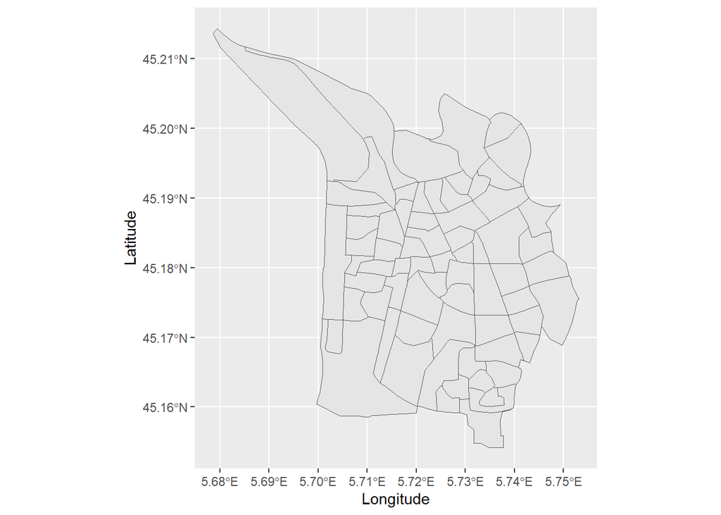

```r
ggplot(data = iris_grenoble) +
  geom_sf() +
  xlab("Longitude") + ylab("Latitude")
```

- Il existe de nombreux critères pour définir le voisinage:

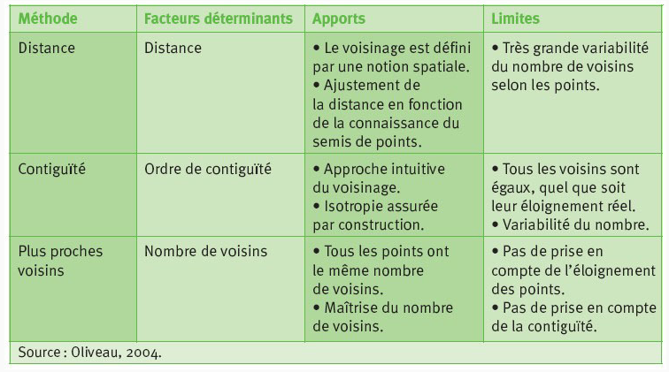

## 1.2. Définir et obtenir la matrice de pondération

- Méthode Rook (adjacence)

```r
if (is.na(sf::st_crs(iris_grenoble))) sf::st_crs(iris_grenoble) <- 4326

liste_voisins_rook <- spdep::poly2nb(iris_grenoble, queen = FALSE)

pts <- sf::st_point_on_surface(iris_grenoble)
```

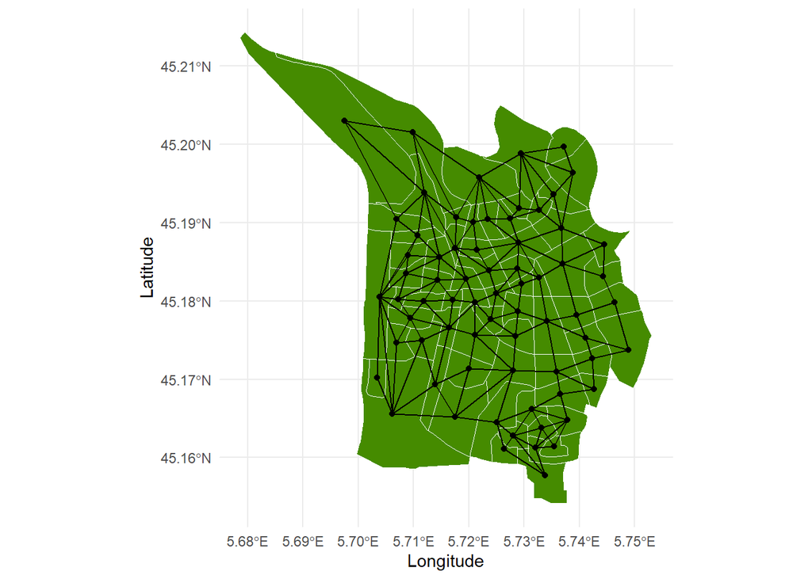

```r
coords <- sf::st_coordinates(pts)

voisins_rook_sf <- sf::st_as_sf(spdep::nb2lines(liste_voisins_rook, coords = coords))
sf::st_crs(voisins_rook_sf) <- sf::st_crs(iris_grenoble)

# 4) Carte
ggplot() +
  geom_sf(data = iris_grenoble, fill = "chartreuse4", color = "white") +
  geom_sf(data = voisins_rook_sf) +
  geom_sf(data = pts) +
  theme_minimal() +
  ylab("Latitude") +
  xlab("Longitude")
```

- Méthode basée sur la distance

```r
if (is.na(sf::st_crs(iris_grenoble))) sf::st_crs(iris_grenoble) <- 4326

pts <- sf::st_point_on_surface(iris_grenoble)
```

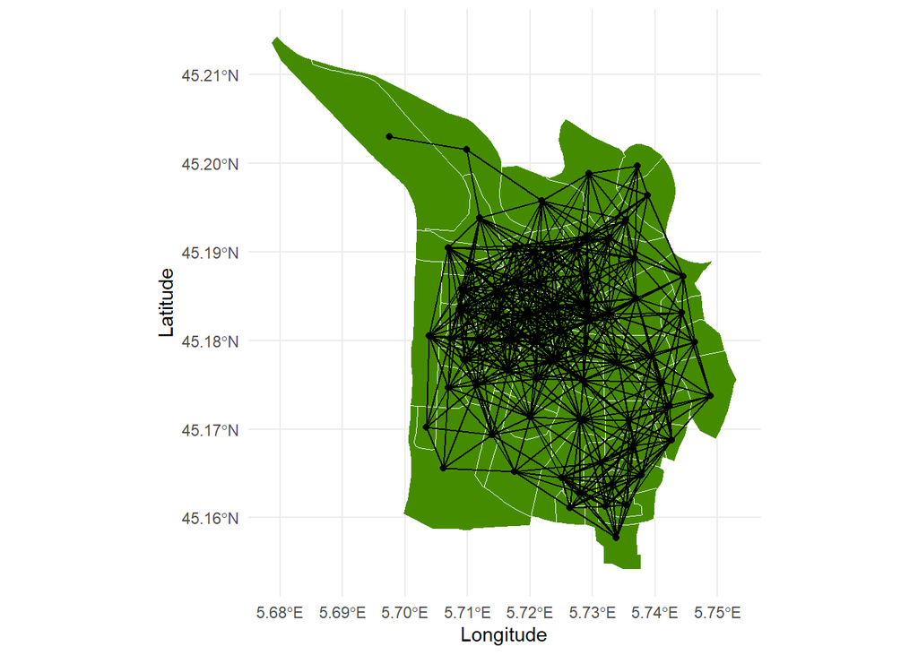

```r
coords <- sf::st_coordinates(pts)

liste_voisins_dist <- spdep::dnearneigh(coords, d1 = 0, d2 = 1.2, longlat = TRUE)

voisins_dist_sf <- sf::st_as_sf(spdep::nb2lines(liste_voisins_dist, coords = coords))
sf::st_crs(voisins_dist_sf) <- sf::st_crs(iris_grenoble)

# Carte
ggplot() +
  geom_sf(data = iris_grenoble, fill = "chartreuse4", color = "white") +
  geom_sf(data = voisins_dist_sf) +
  geom_sf(data = pts) +
  theme_minimal() +
  ylab("Latitude") +
  xlab("Longitude")
```

- Méthode des plus proches voisins

```r
if (is.na(sf::st_crs(iris_grenoble))) sf::st_crs(iris_grenoble) <- 4326

pts <- sf::st_point_on_surface(iris_grenoble)
```

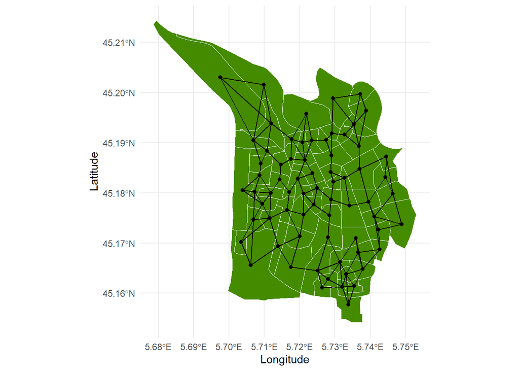

```r
coords <- sf::st_coordinates(pts)

liste_voisins_proche <- spdep::knn2nb(spdep::knearneigh(coords, k = 3))

voisins_proche_sf <- sf::st_as_sf(spdep::nb2lines(liste_voisins_proche, coords = coords))
sf::st_crs(voisins_proche_sf) <- sf::st_crs(iris_grenoble)

# Carte
ggplot() +
  geom_sf(data = iris_grenoble, fill = "chartreuse4", color = "white") +
  geom_sf(data = voisins_proche_sf) +
  geom_sf(data = pts) +
  theme_minimal() +
  ylab("Latitude") +
  xlab("Longitude")
```

- Enfin, on obtient les différentes matrices pondérées

```r
#On transforme les listes de voisins en matrices de pondération normalisées (la somme des poids des voisins de chaque IRIS est égale à 1)
W_rook<-nb2listw(liste_voisins_rook, style="W", zero.policy=TRUE)
W_dist<-nb2listw(liste_voisins_dist, style="W", zero.policy=TRUE)
W_proche<-nb2listw(liste_voisins_proche, style="W", zero.policy=TRUE)
```

## 1.3. Indices de concentration spatial

On distingue deux indices principaux de concentration spatiale (cf. Lecture 3 F.Corolleur), l’entropie relative et l’indice de Moran. Le premier mesure la couverture du territoire étudié alors que le second mesure la corrélation spatiale.

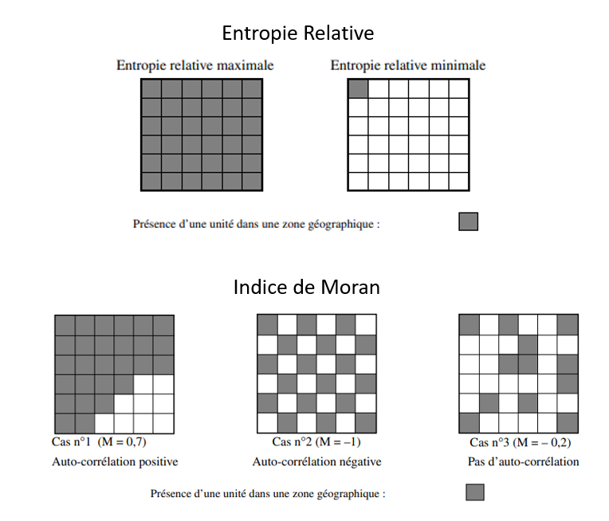

- Entropie relative

Pour l’ensemble des points de vente (enseigne indifférenciée):

```r
nb_pdv_iris<-read.csv("nb_pdv_iris.csv")[,-1]

n_i<-iris_grenoble$nb_supermarche_per_iris
N<-sum(n_i)
f_i<-n_i/N
temp<-f_i*log(f_i)
temp<-ifelse(is.na(temp),0,temp)
E=-sum(temp)
E_r<-E/log(length(n_i))
```

Indice différencié par enseigne

```r
entropy<-matrix(0,nrow=1,ncol=ncol(nb_pdv_iris))
for(i in 1:ncol(nb_pdv_iris)){
  n_i<-nb_pdv_iris[,i]
  N<-sum(n_i)
  f_i<-n_i/N
  temp<-f_i*log(f_i)
  temp<-ifelse(is.na(temp),0,temp)
  E=-sum(temp)
  entropy[i]<-E/log(length(n_i))
}

entropy<-as.data.frame(entropy)
colnames(entropy)<-colnames(nb_pdv_iris)
entropy<-cbind(entropy,E_r)
colnames(entropy)[9]<-"TOTAL"
```

- Indice de Moran

Pour l’ensemble des points de vente (enseigne indifférenciée):

```r
moran.total<-moran.test(iris_grenoble$nb_supermarche_per_iris,W_dist)$estimate[1]
```

Indice de Moran différencié par enseigne

```r
moran<-sapply(nb_pdv_iris,function(x) moran.test(x,W_dist)$estimate)[1,]
moran<-data.frame(t(c(moran,moran.total)))
colnames(moran)<-colnames(entropy)
```

- Tableau de synthèse

```r
indices_concentration<-cbind(c("Entropie","Indice de Moran"),rbind(entropy,moran))
colnames(indices_concentration)[1]<-"Indice"
print(indices_concentration)
```

```
##            Indice   INTERMARCHE        LIDL AUCHAN.SUPERMARCHE      CASINO
## 1        Entropie  0.4894536591  0.25858857         0.65870693  0.51717713
## 2 Indice de Moran -0.0002120168 -0.03930764         0.01979406 -0.03148686
##      SUPER.U        SPAR   CARREFOUR   MONOPRIX     TOTAL
## 1 0.24830442  0.37882540  0.74959117 0.42173978 0.8802259
## 2 0.05532794 -0.05244485 -0.01782985 0.06340555 0.3401240
```

# 2. Econometrie spatiale

On considère généralement un modèle économétrique d’autoregression spatiale (SAR, spatial lag): $y=\rho Wy +\beta X + e$ Ici, $y$ est le nombre de supermarchés par IRIS, et on fait l’hypothèse que cette variable dépend à la fois des charactéristiques de l’IRIS en question (population, niveau de vie, ) et de nombre de supermarchés dans les IRIS voisins. En fonction du critère de voisinage choisi, on utilise la matrice de pondération adéquate.

On peut aussi utiliser un modèle d’erreur spatial (SEM, spatial error dependence): $y=\beta X + e$ avec $e=\lambda We+u$

## 2.1 Test de Moran

On peut tester directement à partir d’un modèle OLS si les erreurs sont autocorrélées en utilisant le test de Moran. On calcule l’indice $I$ de Moran, et si cet indice n’est pas significativement différent de zéro, on ne peut pas rejeter l’hypothèse nulle que les voisins ne co-varient pas.

```r
ols<-lm(nb_supermarche_per_iris~Actif_total+Nb_residence_principale+premier_quartile_revenu, data=iris_grenoble)
summary(ols)
```

```
##
## Call:
## lm(formula = nb_supermarche_per_iris ~ Actif_total + Nb_residence_principale +
##     premier_quartile_revenu, data = iris_grenoble)
##
## Residuals:
##     Min      1Q  Median      3Q     Max
## -2.0506 -0.9257  0.1411  0.4745  4.0961
##
## Coefficients:
##                           Estimate Std. Error t value Pr(>|t|)
## (Intercept)             -9.195e-02  5.877e-01  -0.156  0.87617
## Actif_total             -4.113e-04  1.060e-03  -0.388  0.69933
## Nb_residence_principale  4.312e-04  1.338e-03   0.322  0.74837
## premier_quartile_revenu  1.153e-04  3.418e-05   3.373  0.00128 **
## ---
## Signif. codes:  0 '***' 0.001 '**' 0.01 '*' 0.05 '.' 0.1 ' ' 1
##
## Residual standard error: 1.184 on 63 degrees of freedom
##   (3 observations effacées parce que manquantes)
## Multiple R-squared:   0.16,  Adjusted R-squared:   0.12
## F-statistic: 3.999 on 3 and 63 DF,  p-value: 0.01137
```

```r
moran.lm<-lm.morantest(ols, W_rook, alternative="two.sided")
print(moran.lm)
```

```
##
##  Global Moran I for regression residuals
##
## data:
## model: lm(formula = nb_supermarche_per_iris ~ Actif_total +
## Nb_residence_principale + premier_quartile_revenu, data =
## iris_grenoble)
## weights: W_rook
##
## Moran I statistic standard deviate = 7.1486, p-value = 8.768e-13
## alternative hypothesis: two.sided
## sample estimates:
## Observed Moran I      Expectation         Variance
##      0.512203254     -0.028284410      0.005716518
```

L’indice de Moran est positif et significatif, il y a donc une autocorrélation positive et significative entre les IRIS voisins. Il est intéressant de regarder les résultats du test de Moran en utilisant les autres matrices de pondération spatiale.

```r
#Avec la matrice de pondération en fonction de la distance
moran.lm2<-lm.morantest(ols, W_dist, alternative="two.sided")
print(moran.lm2)
```

```
##
##  Global Moran I for regression residuals
##
## data:
## model: lm(formula = nb_supermarche_per_iris ~ Actif_total +
## Nb_residence_principale + premier_quartile_revenu, data =
## iris_grenoble)
## weights: W_dist
##
## Moran I statistic standard deviate = 6.8126, p-value = 9.582e-12
## alternative hypothesis: two.sided
## sample estimates:
## Observed Moran I      Expectation         Variance
##      0.225735361     -0.023578977      0.001339253
```

```r
#Avec la matrice de pondération des 3 voisins les plus proches
moran.lm3<-lm.morantest(ols, W_proche, alternative="two.sided")
print(moran.lm3)
```

```
##
##  Global Moran I for regression residuals
##
## data:
## model: lm(formula = nb_supermarche_per_iris ~ Actif_total +
## Nb_residence_principale + premier_quartile_revenu, data =
## iris_grenoble)
## weights: W_proche
##
## Moran I statistic standard deviate = 5.7281, p-value = 1.016e-08
## alternative hypothesis: two.sided
## sample estimates:
## Observed Moran I      Expectation         Variance
##      0.482367690     -0.029940827      0.007999119
```

La spécification du voisinage basée sur la distance géographie capture moins bien la corrélation spatiale et les résultats sont très proches pour les matrices d’adjacence et celle des 3 plus proches voisins.

## 2.2 Spécification du modèle économétrique

On peut facilement tester différentes spécifications des modèles d’économétrie spatiale

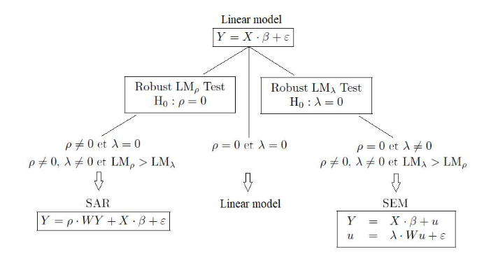

```r
LM<-lm.LMtests(ols, W_rook, test=c("RLMerr","RLMlag"))
```

```
## Please update scripts to use lm.RStests in place of lm.LMtests
```

```r
print(LM)
```

```
##
##  Rao's score (a.k.a Lagrange multiplier) diagnostics for spatial
##  dependence
##
## data:
## model: lm(formula = nb_supermarche_per_iris ~ Actif_total +
## Nb_residence_principale + premier_quartile_revenu, data =
## iris_grenoble)
## test weights: listw
##
## adjRSerr = 0.037774, df = 1, p-value = 0.8459
##
##
##  Rao's score (a.k.a Lagrange multiplier) diagnostics for spatial
##  dependence
##
## data:
## model: lm(formula = nb_supermarche_per_iris ~ Actif_total +
## Nb_residence_principale + premier_quartile_revenu, data =
## iris_grenoble)
## test weights: listw
##
## adjRSlag = 6.111, df = 1, p-value = 0.01343
```

```r
#La p-valeur du test pour le modèle SEM est >0.05, on choisit donc le modèle SAR
```

## 2.3 Estimation

- On estime le modèle SAR avec la matrice d’ajacence

```r
#Estimation via maximum de vraisemblance
sar<-spatialreg::lagsarlm(nb_supermarche_per_iris~Actif_total+Nb_residence_principale+premier_quartile_revenu, data=iris_grenoble, W_rook)
summary(sar)
```

```
##
## Call:spatialreg::lagsarlm(formula = nb_supermarche_per_iris ~ Actif_total +
##     Nb_residence_principale + premier_quartile_revenu, data = iris_grenoble,
##     listw = W_rook)
##
## Residuals:
##       Min        1Q    Median        3Q       Max
## -1.375637 -0.357959 -0.024952  0.260937  3.301109
##
## Type: lag
## Coefficients: (asymptotic standard errors)
##                            Estimate  Std. Error z value Pr(>|z|)
## (Intercept)             -3.1348e-01  3.5990e-01 -0.8710  0.38375
## Actif_total             -1.2655e-04  6.4874e-04 -0.1951  0.84534
## Nb_residence_principale  1.8438e-04  8.1909e-04  0.2251  0.82190
## premier_quartile_revenu  3.8967e-05  2.1511e-05  1.8115  0.07006
##
## Rho: 0.81381, LR test value: 47.436, p-value: 5.6826e-12
## Asymptotic standard error: 0.06801
##     z-value: 11.966, p-value: < 2.22e-16
## Wald statistic: 143.19, p-value: < 2.22e-16
##
## Log likelihood: -80.59502 for lag model
## ML residual variance (sigma squared): 0.52485, (sigma: 0.72446)
## Number of observations: 67
## Number of parameters estimated: 6
## AIC: 173.19, (AIC for lm: 218.63)
## LM test for residual autocorrelation
## test value: 0.028805, p-value: 0.86523
```

```r
#Estimation via 2SLS où on instrument Wy par WX
sar2sls<-spatialreg::stsls(nb_supermarche_per_iris~Actif_total+Nb_residence_principale+premier_quartile_revenu, data=iris_grenoble, W_rook,na.action=na.omit,robust = TRUE)
summary(sar2sls)
```

```
##
## Call:spatialreg::stsls(formula = nb_supermarche_per_iris ~ Actif_total +
##     Nb_residence_principale + premier_quartile_revenu, data = iris_grenoble,
##     listw = W_rook, na.action = na.omit, robust = TRUE)
##
## Residuals:
##       Min        1Q    Median        3Q       Max
## -1.446106 -0.410481 -0.045458  0.252089  3.159710
##
## Coefficients:
##                            Estimate HC0 std. Error z value  Pr(>|z|)
## Rho                      9.5856e-01     1.6681e-01  5.7465 9.111e-09
## (Intercept)             -3.5289e-01     3.2042e-01 -1.1013    0.2708
## Actif_total             -7.5904e-05     5.7326e-04 -0.1324    0.8947
## Nb_residence_principale  1.4048e-04     7.6526e-04  0.1836    0.8543
## premier_quartile_revenu  2.5391e-05     2.2286e-05  1.1394    0.2545
##
## Residual variance (sigma squared): 0.51907, (sigma: 0.72047)
## Anselin-Kelejian (1997) test for residual autocorrelation
## test value: 0.86254, p-value: 0.35303
```

- On obtient les effets marginaux prenant en compte la dépendance spatiale

```r
spatialreg::impacts(sar, tr=as(W_rook, "CsparseMatrix"))
```

```
## Impact measures (lag, trace):
##                                Direct      Indirect         Total
## Actif_total             -1.266603e-04 -0.0005530230 -0.0006796833
## Nb_residence_principale  1.845449e-04  0.0008057584  0.0009903033
## premier_quartile_revenu  3.900164e-05  0.0001702887  0.0002092903
```

```r
spatialreg::impacts(sar2sls, tr=as(W_rook, "CsparseMatrix"))
```

```
## Impact measures (lag, trace):
##                                Direct      Indirect         Total
## Actif_total             -7.623424e-05 -0.0017554714 -0.0018317056
## Nb_residence_principale  1.410955e-04  0.0032490541  0.0033901497
## premier_quartile_revenu  2.550190e-05  0.0005872407  0.0006127426
```

- Et les résidus

```r
iris_grenoble$ols_res<-ifelse(is.na(iris_grenoble$premier_quartile_revenu),NA,resid(ols)) #les modèles économétriques enlèves automatiquements les lignes avec des NA
iris_grenoble$sar_res<-ifelse(is.na(iris_grenoble$premier_quartile_revenu),NA,resid(sar)) #les modèles économétriques enlèves automatiquements les lignes avec des NA

iris_grenoble2<-iris_grenoble
tmap_mode("view")
```

```
## ℹ tmap mode set to "view".
```

```r
tm_shape(iris_grenoble) +tm_text(text = "iris_name",size=0.8)+
  tm_polygons("ols_res", alpha=0.5,palette="-RdYlBu",
              style="pretty", id="iris_name",
              title="Résidus OLS")+
  tm_shape(iris_grenoble2) +tm_text(text = "iris_name",size=0.8)+
  tm_polygons("sar_res", alpha=0.5,palette="-RdYlBu",
              style="pretty", id="iris_name",
              title="Résidus SAR")
```

[output not shown]

[interactive chart not shown]